# cFDR

Anna Hutchinson

09/12/2019

### 1. Introduction

**Aim:** Take a set of P values for association with a given disease ($p_1,...,p_n \in (0,1]$) and a set of binary covariates measuring overlap with an active mark in a given cell type ($q_1,...,q_n$) and transform the P values into values $v_1,...,v_n$ such that for all $\alpha$

$$\begin{equation}
Pr(v_i<\alpha| H_0)=\alpha
\end{equation}$$

$$\begin{equation}
Pr(v_i<\alpha| H_1)\text{ is maximal}.
\end{equation}$$

**Method:** Choose a set of rejection regions, and for each $(p_i, q_i)$ pair find the smallest rejection region in which $(p_i, q_i)$ is contained. Estimate the distribution of P, Q under the null and integrate this over the selected rejection region to get $v_i$.

### 2. Notation

$H$ denotes a hypothesis of association with T1D; $H=1$ indicates association, $H=0$ indicates no association (null hypothesis).

$$\begin{equation}
H \sim \text{Bernoulli}(\pi_1) \Longrightarrow P(H=1)=\pi_1
\end{equation}$$

$$\begin{equation}
\begin{split}
Q|H=0 \sim \text{Bernoulli}(q_1) & \Longrightarrow P(Q=1|H=0)=q_1 \\
& \Longrightarrow P(Q=0|H=0)=1-q_1=q_0
\end{split}
\end{equation}$$

$$\begin{equation}
P|H=0 \sim U(0,1)
\end{equation}$$

$$\begin{equation}
P \perp Q|H = 0
\end{equation}$$

$$\begin{equation}
f(P=p, Q=q|H_0)=f_0(p,q)
\end{equation}$$

$$\begin{equation}
f(P=p, Q=q|H_1)=f_1(p,q)
\end{equation}$$

$$\begin{equation}
f(P=p, Q=q)=f_0(p,q)(1-\pi_1)+f_1(p,q)\pi_1=f(p,q)
\end{equation}$$

### 3. Detailed method

#### 1. Generate the set of possible rejection regions.

Since $Q$ can only be 0 or 1, we just need two P value thresholds, $p_0$ for $Q=0$ and $p_1$ for $Q=1$.

$$\begin{equation}
L(p_0, p_1)=(P\leq p_0, Q=0) \cup (P\leq p_1, Q=1).
\end{equation}$$

#### 2. Pick the smallest rejection region that $(p[i], q[i])$ belongs.

Following on from our aim, we want the rejection region such that:

a.) the probability of a null instance of $P,Q$ falling inside $L(p_0, p_1)$ is fixed at some value $\alpha$, that is

$$\begin{equation}
\int_{L(p_0, p_1)}df_0=\alpha
\end{equation}$$

b.) the probability of a non-null instance of $P,Q$ falling inside $L(p_0, p_1)$ is maximal, that is

$$\begin{equation}
\int_{L(p_0, p_1)}df_1 \text{ is maximal}
\end{equation}$$

Previous works (e.g. appendix 8.1 in [James’ paper](https://www.biorxiv.org/content/10.1101/414318v3)) show that this optimal region is given by the set of points $\{(p,q):f_0(p,q)/f_1(p,q)\leq k_{\alpha}\}$ which means that in our case, the chosen $p_0$ and $p_1$ should satisfy

$$\begin{equation}
\dfrac{f_0(p_0,0)}{f(p_0,0)}=\dfrac{f_0(p_1,1)}{f(p_1,1)}
\end{equation}$$

(using $f(p,q)=f_0(p,q)(1-\pi_1)+f_1(p,q)\pi_1$).

But how do we find $p_0$ and $p_1$ that satisfy this equation? James provides 2 options:

**Option 1: Estimate $f$ directly**

Consider
$$\begin{equation}
\begin{split}
g(p,q) & = \dfrac{f_0(p,q)}{f(p,q)} \\[2ex]
& = \dfrac{f(P=p, Q=q|H_0)}{f(p,q)} \\[2ex]
& = \dfrac{f(P=p|Q=q, H_0) f(Q=q|H_0)}{f(p,q)}
\end{split}
\end{equation}$$

then since the P values are distributed uniformly under the null, $f(P=p|Q=q, H_0)=1$. We can also estimate $f(Q=q|H_0)$ by $q_0$ or $q_1$ depending on the value of $q$.

Side note: Looking at the denominator, we know

$$\begin{equation}
\color{gray}{f(p,q)=f_0(p,q)(1-\pi_1)+f_1(p,q)\pi_1.}
\end{equation}$$

If we assume the event to be rare then $\pi_1\approx 0$ which leaves

$$\begin{equation}
\color{gray}{f(p,q)\approx f_0(p,q)}
\end{equation}$$

which would cancel with the numerator in $g$????

James suggests that the denominator can be estimated by

$$\begin{equation}
\hat{f}(p,q) = \hat{f}(p|q=0)q_0 + \hat{f}(p|q=1)q_1,
\end{equation}$$

using KDE. So that,

$$\begin{equation}
g(p,q)=\dfrac{f_0(p,q)}{f(p,q)} \approx \hat{g}(p,q) = \left\{\begin{array}{ll}{\dfrac{q_0}{\hat{f}(p,q)}} & {\text{ if }q = 0} \\ {\dfrac{q_1}{\hat{f}(p,q)}} & {\text{ if }q = 1}\end{array}\right.
\end{equation}$$

I’m not entirely sure how KDE works but surely this gives

$$\begin{equation}
\hat{g}(p,q) = \left\{\begin{array}{ll}{\dfrac{q_0}{\hat{f}(p,q)}=\dfrac{q_0}{\hat{f}(p|q=0)q_0}=\dfrac{1}{\hat{f}(p|q=0)}} & {\text{ if }q = 0} \\ {\dfrac{q_1}{\hat{f}(p,q)}=\dfrac{q_1}{\hat{f}(p|q=1)q_1}=\dfrac{1}{\hat{f}(p|q=1)}} & {\text{ if }q = 1}\end{array}\right.
\end{equation}$$

He then suggests that if $q[i]=1$ in our $(p[i],q[i])$ pair we are trying to find $v_i$ for, then we should set $p_1=p[i]$ and solve

$$\begin{equation}
\hat{g}(p_0,0)=\hat{g}(p[i],1)
\end{equation}$$

for $p_0$. I.e. solve,

$$\begin{equation}
\begin{aligned}
\hat{f}(p_0|q=0)=\hat{f}(p[i]|q=1)
\end{aligned}
\end{equation}$$

Similarly, if $q[i]=0$ he suggests setting $p_0=p[i]$ and solving

$$\begin{equation}
\hat{g}(p[i],0)=\hat{g}(p_1,1)
\end{equation}$$

to find $p_1$. And similarly,

$$\begin{equation}
\begin{aligned}
\hat{f}(p[i]|q=0)=\hat{f}(p_1|q=1)
\end{aligned}
\end{equation}$$

**Option 2: cFDR (CDF) approach**

Rather than estimating $f$ directly, we can follow the cFDR approach. This approach is again concerned with choosing $p_0$ and $p_1$ that satisfy

$$\begin{equation}
\dfrac{f_0(p_0,0)}{f(p_0,0)}=\dfrac{f_0(p_1,1)}{f(p_1,1)}.
\end{equation}$$

Approximate,

$$\begin{equation}
\begin{split}
\dfrac{f_0(p,q)}{f(p,q)} &= \dfrac{f(P=p, Q=q|H_0)}{f(P=p, Q=q)} \\
& \approx \dfrac{Pr(P\leq p, Q=q|H_0)}{Pr(P\leq p, Q=q)} \\
& \approx \dfrac{Pr(P\leq p| Q=q, H_0)Pr(Q=q|H_0)}{Pr(P\leq p|Q=q)Pr(Q=q)} \\
& \approx \dfrac{p Pr(Q=q|H_0)}{Pr(P\leq p|Q=q)\times(Pr(Q=q|H_0)Pr(H_0)+Pr(Q=q|H_1)Pr(H_1))}
\end{split}
\end{equation}$$

Note that,

$$\begin{equation}
Pr(Q=q|H_0) = \left\{\begin{array}{ll}{q_0} & {\text{ if }q = 0} \\ {q_1} & {\text{ if }q = 1}\end{array}\right.
\end{equation}$$

so we can use our empirical estimates of these. Moreover, if we assume that the event is rare, then $Pr(H_0)\approx 1$ and $Pr(H_1)\approx 0$. Therefore, the denominator reduces to $Pr(P\leq p|Q=q)\times q_0$ if $q=0$ or $Pr(P\leq p|Q=q)\times q_1$ if $q=1$ where the first term can be empirically estimated by counting.

Set $\hat{h}(p,q)$ equal to this approximation and note that

$$\begin{equation}
\hat{h}(p,q) = \left\{\begin{array}{ll}{\dfrac{p}{\hat{Pr}(P\leq p|Q=0)}} & {\text{ if }q = 0} \\ {\dfrac{p}{\hat{Pr}(P\leq p|Q=1)}} & {\text{ if }q = 1}\end{array}\right.
\end{equation}$$

Again, if $q[i]=1$ then we set $p_1=p[i]$ and solve $\hat{h}(p_0,0)=\hat{h}(p_i,1)$ for $p_0$, i.e.

$$\begin{equation}
\dfrac{p_0}{Pr(P\leq p_0|Q=0)}=\dfrac{p[i]}{Pr(P\leq p[i]|Q=1)}
\end{equation}$$

and if $q[i]=0$ then we set $p_0=p[i]$ and solve $\hat{h}(p[i],0)=\hat{h}(p_1,1)$ for $p_1$, i.e.

$$\begin{equation}
\dfrac{p[i]}{Pr(P\leq p[i]|Q=0)}=\dfrac{p_1}{Pr(P\leq p_1|Q=1)}
\end{equation}$$

but how would I solve this for $p_0$ and $p_1$?

#### 3. Integrate the null distribution over this region to get $v$.

$$\begin{equation}
\begin{split}
\int_{L(p_0,p_1)}df_0 & = Pr(P,Q \in L(p_0, p_1)|H_0) \\
& = Pr((P\leq p_0, Q=0) \cup (P\leq p_1, Q=1) | H_0) \\
& = Pr(P\leq p_0, Q=0|H_0) + Pr(P\leq p_1, Q=1|H_1) \\
& = Pr(P\leq p_0|Q=0, H_0)Pr(Q=0|H_0) + Pr(P\leq p_1|Q=1, H_0)Pr(Q=1|H_0) \\
& = p_0\times q_0 + p_1\times (1-q_0)
\end{split}
\end{equation}$$

The last line follows from the fact that under the null, the P values are uniform and independent of Q (so that $Pr(P\leq p_i|Q=0/1, H_0)=p_i$). We set $Pr(Q=0|H_0)=q_0$ and note that $q_0$ can be estimated by the number of $Q=0$ in the data. This means that we only need to find $p_0$ and $p_1$ and we can derive,

$$\begin{equation}
v_i=p_0\hat{q_0}+p_1(1-\hat{q_0}).
\end{equation}$$

### 4. Data

I have data for 16,000 SNPs (from 39 T1D associated regions) consisting of P values (and PPs) measuring strength of evidence of association with T1D and a binary indicator of whether that SNP overlaps and active chromatin annotation for 19 different cell types.

```r
x <- readRDS("binary_annots.RDS")
x[1:5, 1:5]
```

```
##             snps         P           PP THYMUS PANISLETS
## 1 imm_7_50868985 0.7040051 3.710506e-10      0         0
## 2 imm_7_50869125 0.6381124 4.490570e-10      0         0
## 3 imm_7_50870347 0.2296590 1.466098e-09      0         0
## 4 imm_7_50870355 0.7335254 9.073471e-10      0         0
## 5 imm_7_50871208 0.9917130 3.460071e-10      0         0
```

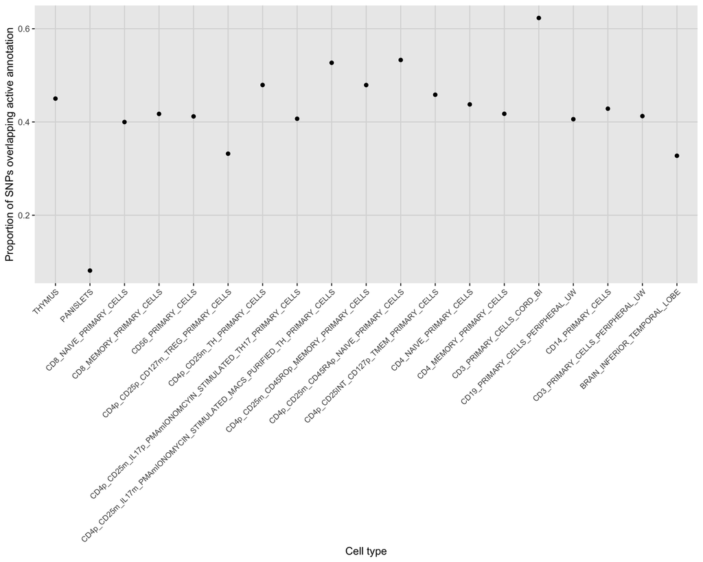

I’ve already investigated using logistic and quantile regression approaches to explore the relationship between P values and active/ inactive marks in the 19 cell types. My results were weird though, with active marks in the brain indicative of smaller P values, and active marks in the thymus indicative of larger P values for T1D.

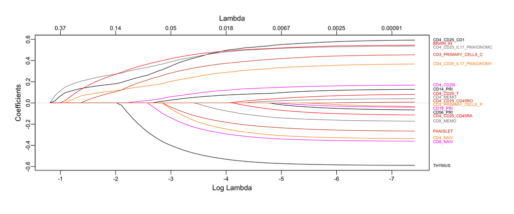

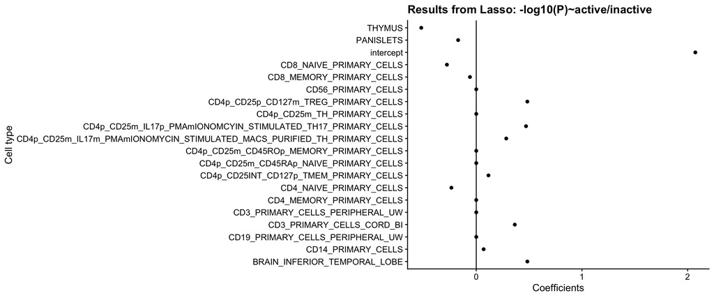

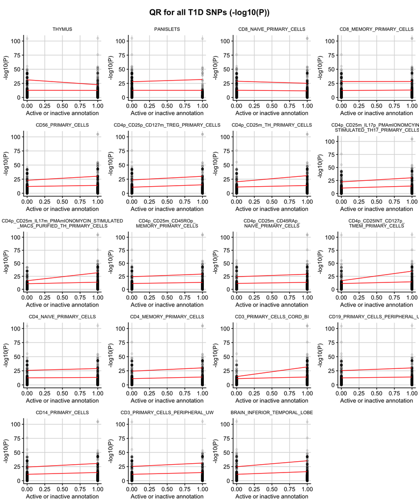

For now, let’s just use the binary annotation data for thymus cells for our cFDR approach.

```r
x <- readRDS("binary_annots.RDS")
data <- na.omit(x[,c(1,2,4)])
colnames(data) <- c("snp","p","q")
head(data)
```

```
##              snp         p q
## 1 imm_7_50868985 0.7040051 0
## 2 imm_7_50869125 0.6381124 0
## 3 imm_7_50870347 0.2296590 0
## 4 imm_7_50870355 0.7335254 0
## 5 imm_7_50871208 0.9917130 0
## 6 imm_7_50871428 0.2443444 0
```

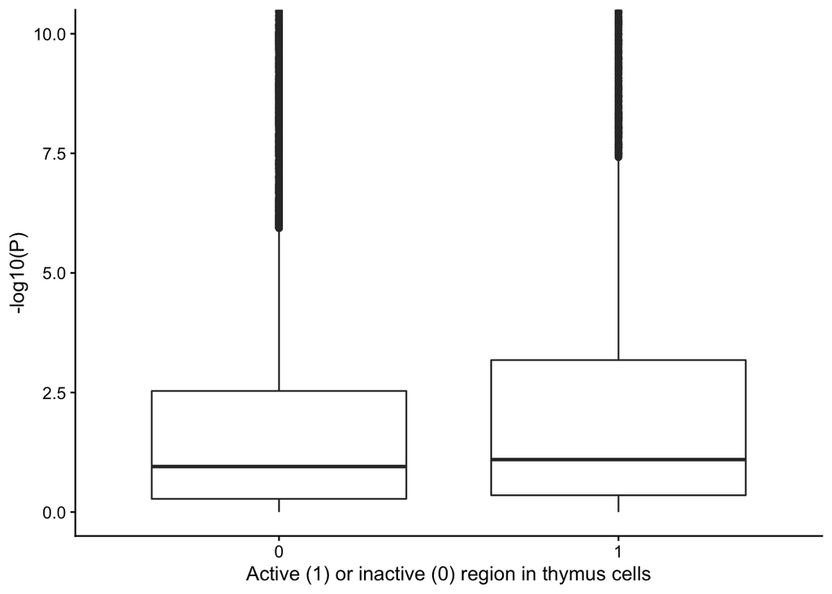

### 5. Implementation (walkthrough example 1)

Aim: Find $v_1$.

To estimate $v_i$ we leave out $(p[i], q[i])$ so I omit $(p[1], q[1])$. I then estimate $q_0=Pr(Q=0|H_0)$ by the proportion of SNPs with non-active binary annotation and $q_1=Pr(Q=1|H_0)$ by the proportion of SNPs with active binary annotation.

```r
p <- data$p
q <- data$q
i = 1
data_i <- data[i,]
data_i
```

```
##              snp         p q
## 1 imm_7_50868985 0.7040051 0
```

```r
data_cut <- data[-i,]
q0 <- length(which(data_cut$q==0))/length(data_cut$q)
q1 <- length(which(data_cut$q==1))/length(data_cut$q)
c(q0, q1)
```

```
## [1] 0.5080645 0.4919355
```

Next, I need to find $p_0$ and $p_1$. James suggests that since $q[i=1]=0$ here, I should set $p_0=p[i=1]$ and then solve

$$\begin{equation}
\hat{g}(p[i=1],0)=\hat{g}(p_1,1)
\end{equation}$$

to find $p_1$ (I am using option 1 (pdfs) for now). I.e. solve the following for $p_1$

$$\begin{equation}
\hat{f}(p[i]|q=0)=\hat{f}(p_1|q=1)
\end{equation}$$

First, I visualise the KDEs and see if the P values look normal, they do not…

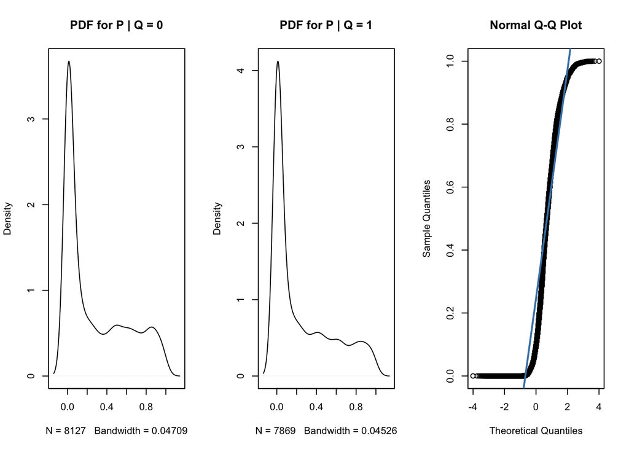

```r
par(mfrow=c(1,3))

# P|Q=0
dens_q0 = density(data_cut[which(data_cut$q==0),"p"])
plot(dens_q0, main = "PDF for P | Q = 0")

# P|Q=1
dens_q1 = density(data_cut[which(data_cut$q==1),"p"])
plot(dens_q1, main = "PDF for P | Q = 1")

qqnorm(data$p)
qqline(data$p, col = "steelblue", lwd = 2)
```

anyway..

```r
p0 <- p[i]
f_pi_q0 <- approx(dens_q0$x, dens_q0$y, xout = p0)$y

# use interpolation to find p1
approxs <- approx(dens_q1$x, dens_q1$y, n = 1000)

# remove P<0

approxs_x <- approxs$x[which(approxs$x>0)]
approxs_y <- approxs$y[which(approxs$x>0)]

p1 <- approxs_x[which(abs(approxs_y-f_pi_q0)==min(abs(approxs_y-f_pi_q0)))]
```

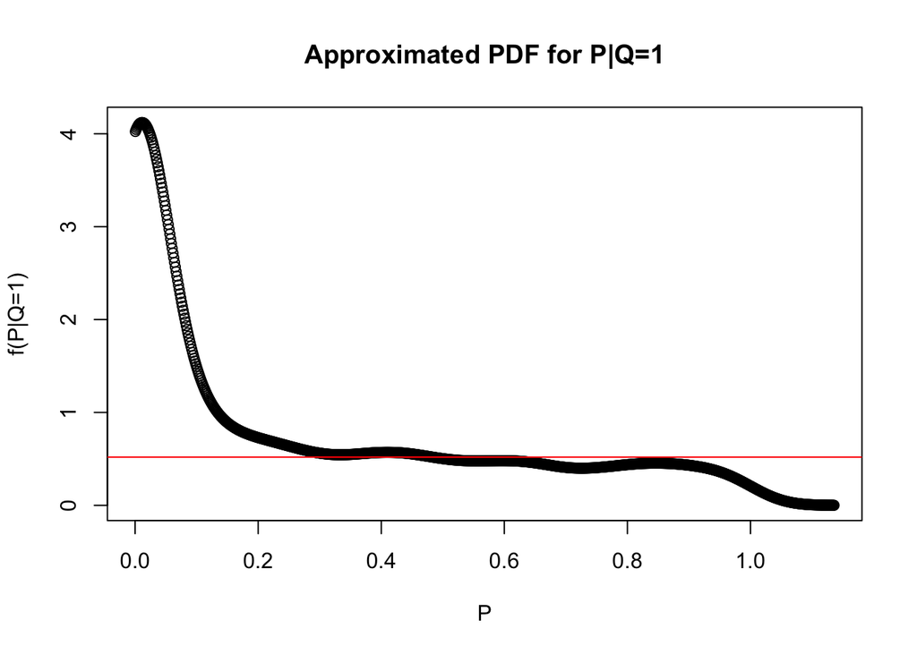

```r
par(mfrow=c(1,1))
plot(approxs_x, approxs_y, xlab = "P", ylab = "f(P|Q=1)", main = "Approximated PDF for P|Q=1")
abline(h = f_pi_q0, col = "red")
```

But it hits the curve loads of times? Which one should I use?

Finally, I find $v_i$.

```r
v1 <- (p0*q0) + p1*(1-q0)

data.frame(v = v1, p = p[i], q = q[i])
```

```
##           v         p q
## 1 0.5958209 0.7040051 0
```

### 6. Implementation (walkthrough example 2)

I do another walkthrough example for a (p,q) pair with $q=1$ to see if the P value decreases as expected… Hmm, it doesnt. And note that the solution doesn’t even hit the density function!

```r
p <- data$p
q <- data$q
i = 1989
data_i <- data[i,]
data_i
```

```
##                 snp            p q
## 2106 imm_5_35918933 0.0001164736 1
```

```r
data_cut <- data[-i,]
q0 <- length(which(data_cut$q==0))/length(data_cut$q)
q1 <- length(which(data_cut$q==1))/length(data_cut$q)

dens_q0 = density(data_cut[which(data_cut$q==0),"p"])
dens_q1 = density(data_cut[which(data_cut$q==1),"p"])

p1 <- p[i]

f_pi_q1 <- approx(dens_q1$x, dens_q1$y, xout = p1)$y
f_pi_q1
```

```
## [1] 4.018477
```

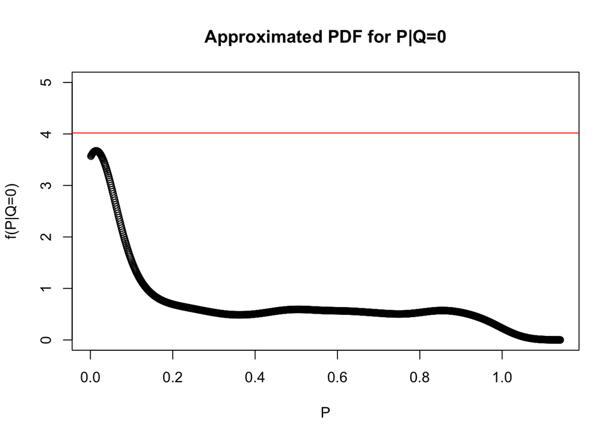

```r
# use interpolation to find p0
approxs <- approx(dens_q0$x, dens_q0$y, n = 1000)

# remove P<0

approxs_x <- approxs$x[which(approxs$x>0)]
approxs_y <- approxs$y[which(approxs$x>0)]

p0 <- approxs_x[which(abs(approxs_y-f_pi_q1)==min(abs(approxs_y-f_pi_q1)))]

par(mfrow=c(1,1))
plot(approxs_x, approxs_y, xlab = "P", ylab = "f(P|Q=0)", main = "Approximated PDF for P|Q=0", ylim = c(0,5))
abline(h = f_pi_q1, col = "red")
```

```r
v1 <- (p0*q0) + p1*(1-q0)

data.frame(v = v1, p = p[i], q = q[i])
```

```
##             v            p q
## 1 0.007197406 0.0001164736 1
```

### 7. Full implementation

I now write code to perform this method for all $(p,q)$ value pairs in my data set (P values for T1D and binary annotation for active chromatin in thymus cells).

```r
x <- readRDS("binary_annots.RDS")
data <- na.omit(x[,c(1,2,4)])
colnames(data) <- c("snp","p","q")

v <- vector("numeric", dim(data)[1]) # prepare a container

cFDR_v <- for(i in 1:nrow(data)){
  pi <- data$p[i]
  qi <- data$q[i]

  data_cut <- data[-i,]

  q0 <- length(which(data_cut$q==0))/length(data_cut$q)
  q1 <- length(which(data_cut$q==1))/length(data_cut$q)

  dens_q0 = density(data_cut[which(data_cut$q==0),"p"])

  dens_q1 = density(data_cut[which(data_cut$q==1),"p"])

  if(qi == 0){
    p0 = pi

    f_pi_q0 <- approx(dens_q0$x, dens_q0$y, xout = p0)$y

    # use interpolation to find p1
    approxs <- approx(dens_q1$x, dens_q1$y, n = 1000)

    # remove P<0

    approxs_x <- approxs$x[which(approxs$x>0)]
    approxs_y <- approxs$y[which(approxs$x>0)]

    p1 <- approxs_x[which(abs(approxs_y-f_pi_q0)==min(abs(approxs_y-f_pi_q0)))]

  } else{
    p1 <- p[i]

    f_pi_q1 <- approx(dens_q1$x, dens_q1$y, xout = p1)$y

    # use interpolation to find p0
    approxs <- approx(dens_q0$x, dens_q0$y, n = 1000)

    # remove P<0

    approxs_x <- approxs$x[which(approxs$x>0)]
    approxs_y <- approxs$y[which(approxs$x>0)]

    p0 <- approxs_x[which(abs(approxs_y-f_pi_q1)==min(abs(approxs_y-f_pi_q1)))]
  }
  v[i] <- (p0*q0) + p1*(1-q0)
}
```

Oh dear.. at least it’s pretty.

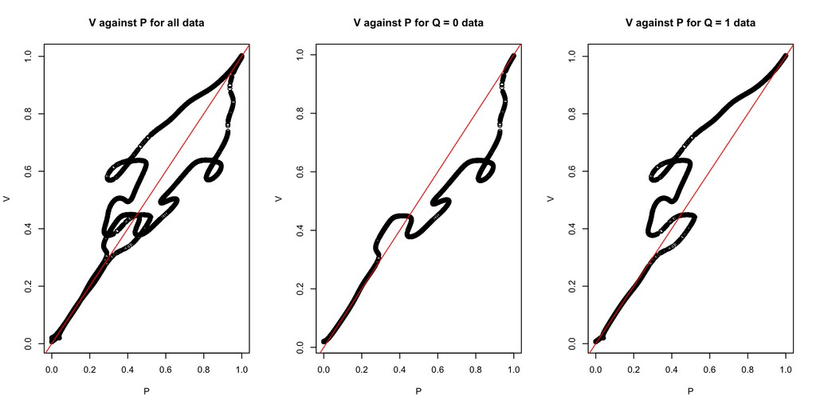